# Индивидуальный проект. Этап 1.

Установка Kali Linux на Virtualbox

Дагделен З. Р.

Российский университет дружбы народов, Москва, Россия

27 февраля 2025

## Докладчик

- Дагделен Зейнап Реджеповна
- студентка из группы НКАбд-02-23
- Факультет физико-математических и естественных наук
- Российский университет дружбы народов
- 1132236052@rudn.ru

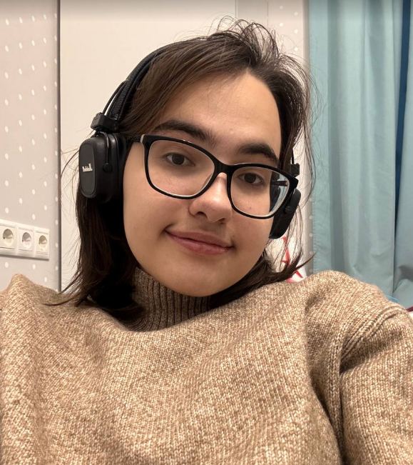

## Цель

Приобретение практических навыков по установке операционной системы Linux на виртуальную машину.

## Задание

1. Установить дистрибутив Kali Linux на виртуальную машину VirtualBox.

## Выполнение лабораторной работы

Открываю VirtualBox(рис. 1).

[figure not shown]

Выбор имени и операционной системы

## Выполнение лабораторной работы

Настраиваю основную память и количество выделяемых процессоров(рис. 2).

[figure not shown]

Настройка оборудования виртуальной машины

## Выполнение лабораторной работы

Настраиваю размер виртуального жесткого диска, выбираю 40ГБ (рис. 3).

[figure not shown]

Настройка размера виртуального жесткого диска

## Выполнение лабораторной работы

[figure not shown]

Выбор способа установки

## Выполнение лабораторной работы

Выбираю язык, на котором будет установка (рис. 5).

[figure not shown]

Выбор языка установки

## Выполнение лабораторной работы

Ввожу имя компьютера (рис. 6).

[figure not shown]

Ввод имени компьютера

## Выполнение лабораторной работы

Ввожу имя домена (рис. 7).

[figure not shown]

Ввод имени домена.

## Выполнение лабораторной работы

Ввожу имя пользователя, у которой будут права суперпользователя (рис. 9).

[figure not shown]

Настройка учетной записи

## Выполнение лабораторной работы

Ввожу пароль для созданного пользователя (рис. 10).

[figure not shown]

Настройка пароля

## Выполнение лабораторной работы

Теперь установщик проверяет диски и предлагает различные варианты, в зависимости от настроек. Созданный виртуальный диск чистый, поэтому я выбираю «весь диск» (рис. 11).

[figure not shown]

Разметка дисков

## Выполнение лабораторной работы

Подтверждаю установку системного загрузчика GRUB (Загрузчик операционной системы от проекта GNU программа для управления процессом загрузки), также выбираю виртуальный диск, на который устанавливать GRUB (рис. 12).

[figure not shown]

Установка системного загрузчика

## Выполнение лабораторной работы

Завершаю установку.

Проверяю, что в носителях теперь пусто (рис. 13).

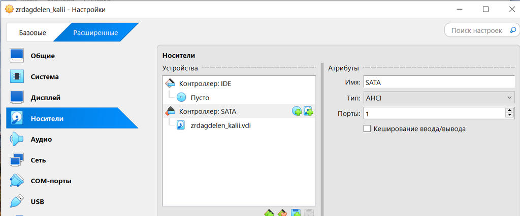

Проверка носителей

## Выполнение лабораторной работы

Вхожу в систему от имени своего пользователя (рис. 21).

[figure not shown]

Вход в систему

Это успех!

# Выводы

Приобрела практические навыки по установке операционной системы Linux на виртуальную машину. Установила дистрибутив Kali LInux на VirtualBox.